# lab3

Evgeniya Lukyanova

## Задание 1 (14 вариант)

data2.csv, data1.txt Объедините data.frames по идентификаторам сортов. Исключите те сорта, для которых есть пропущенные значения. Для всех наблюдаемых величин из файла test_data1.txt (из первого дз), в которых содержится не более 80% пропущенных значений нарисовать гистограммы. Найтите корреляции Пирсона для количественных переменных. Постройте тепловую карту (heatmap).

data2.csv, data1.txt Объедините data.frames по идентификаторам сортов. Исключите те сорта, для которых есть пропущенные значения.

```r
library(stringr)
library(tidyr)
```

```r
library(ggplot2)
setwd("./data")

countable_signs_unf <- read.csv("data2.csv")
countable_signs <- countable_signs_unf |> pivot_longer(!X, names_to = "Sample", values_to = "vals", values_drop_na = TRUE) |>
  pivot_wider(names_from = X, values_from = vals)

quality_signs_unf <- read.table("data1.txt", header = TRUE, skip = 1,)
quality_signs <- quality_signs_unf[, colnames(quality_signs_unf)[2:5]] |> drop_na()

res <- merge(countable_signs, quality_signs, by = "Sample")

res
```

```
##    Sample GrowthType Polegaemost GenmBMatur MaturType Height Protein  Oil
## 1     V_0          0           1        123         5   92.5    39.8 16.5
## 2   V_100          1           0         95         2   62.5    41.8 20.9
## 3    V_11          1           0         92         2   42.5    40.7 15.1
## 4    V_12          2           2        133         5   97.5    43.1 18.4
## 5    V_13          0           0        118         4   92.5    42.6 20.2
## 6    V_14          0           2        113         4   82.5    42.4 19.5
## 7    V_17          2           0        131         5  107.5    42.7 16.7
## 8    V_19          1           0         95         2   57.5    39.8 18.3
## 9     V_2          0           0        137         5  112.5    42.1 18.3
## 10   V_20          2           0        102         3   52.5    41.1 21.3
## 11   V_21          1           0        121         5   62.5    39.7 21.9
## 12   V_22          2           0        118         4   87.5    40.8 20.4
## 13   V_23          2           0        136         5   82.5    41.0 20.8
## 14   V_24          1           0        108         3   47.5    44.3 19.1
```

[output cut: 72 more lines]

Для всех наблюдаемых величин из файла data1.txt (из первого дз), в которых содержится не более 80% пропущенных значений нарисовать гистограммы.

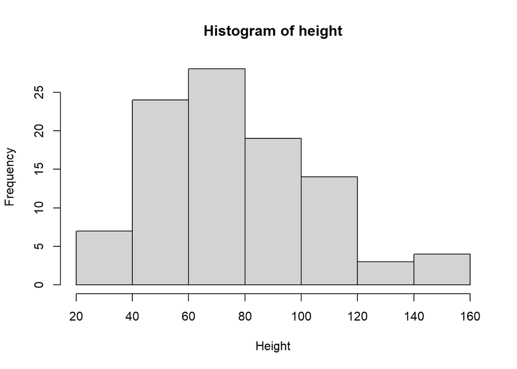

```r
setwd("./data")

df <- read.table("data1.txt", header = TRUE, skip = 1,)
df <- quality_signs_unf[, colnames(quality_signs_unf)[2:5]]
# Условие про 80 процентов очень странное, там везде меньше 80 процентов
# Строим гистограмму для Height:
hist(df$Height, main = "Histogram of height", xlab = "Height")
```

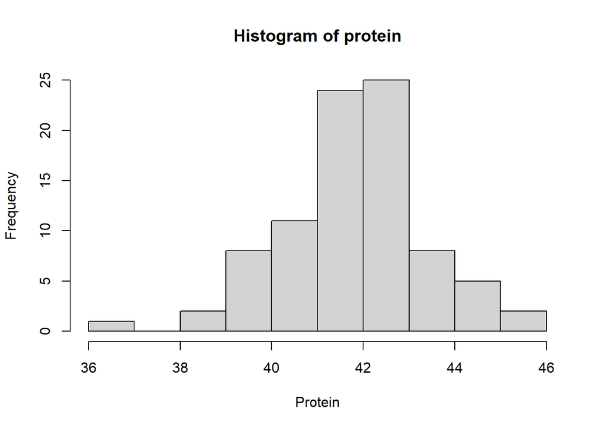

```r
# Строим гистограмму для Height:
hist(df$Protein, main = "Histogram of protein", xlab = "Protein")
```

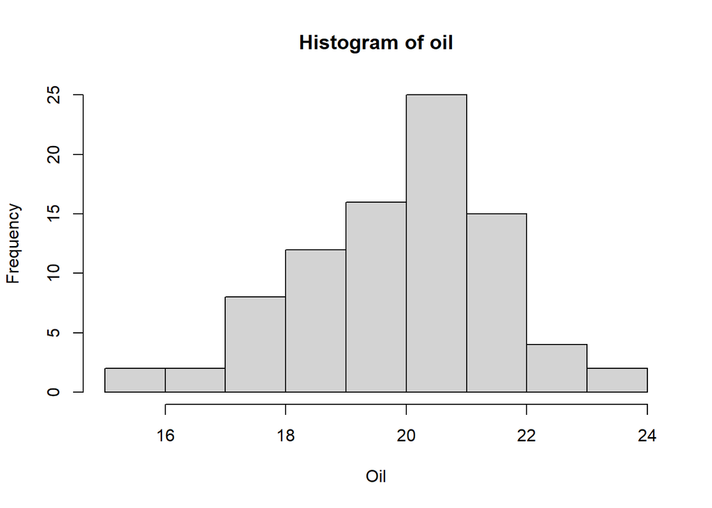

```r
# Строим гистограмму для Height:
hist(df$Oil, main = "Histogram of oil", xlab = "Oil")
```

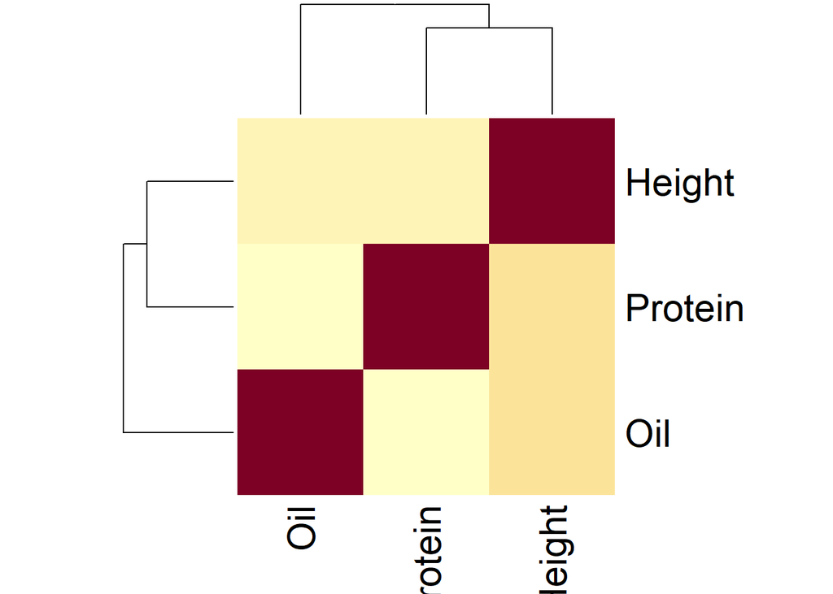

```r
fixed <- drop_na(df)[2:4]
cormat <- cor(fixed)
heatmap(cormat)
```

## Задание 2 (5 вариант)

trades.RData

1. Объедините таблицы в одну, уберите столбец с территорией торговли, т.к. там только Евросоюз, оставим только строки с экспортом и импортом, вынесете данные по экспорту и импорту в отдельные переменные.
2. Отобразите структуру экспорта продукции из Евросоюза по ведущим партнерам в виде круговых диаграмм на одном рисунке.

Обозначьте разные группы экспортируемых товаров разными цветами.

3. Для каждого партнера подпишите значение экспорта.
4. Отрегулируйте местоположение подписей так, чтобы рисунок был максимально наглядным. Придумайте новые названия графика и осей.

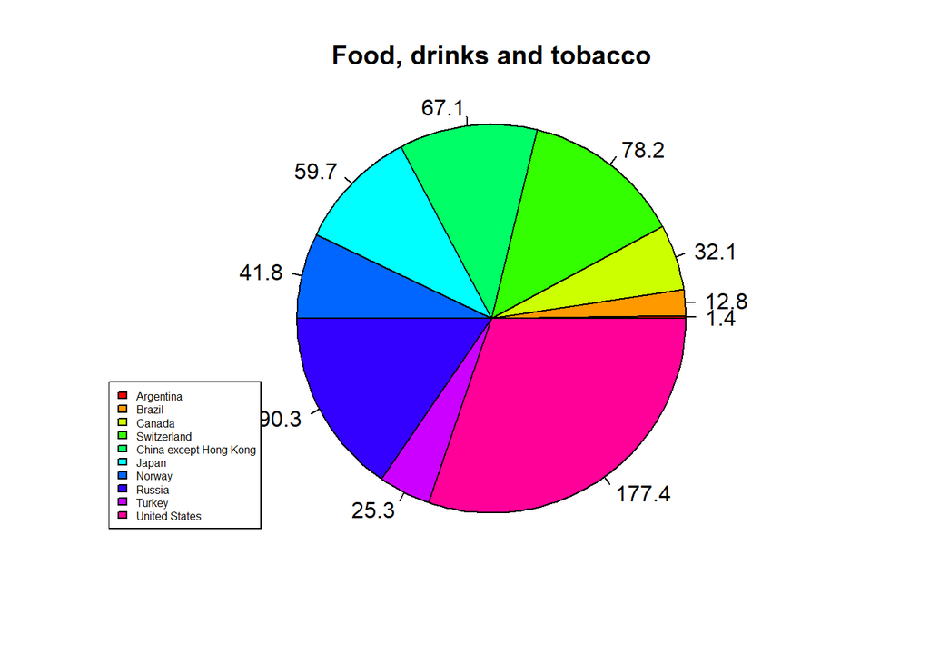

```r
setwd("./data")
load("trades.Rdata")
#1
len = length(trades)
rdf <- trades[[1]]
for (i in seq(2, len)){
  rdf <- rbind(rdf, trades[[i]])
}
rdf <- subset(rdf, select = - c(geo))
importdf = rdf[rdf$indic_et == 'Share of imports by partner (%)',]
exportdf = rdf[rdf$indic_et == 'Share of exports by partner (%)',]


food <- exportdf[exportdf$sitc06 == 'Food, drinks and tobacco',]
food <- subset(food, select = - c(indic_et, sitc06, time))
math <- exportdf[exportdf$sitc06 == 'Raw materials',]
math <- subset(math, select = - c(indic_et, sitc06, time))
mineral <- exportdf[exportdf$sitc06 == 'Mineral fuels, lubricants and related materials',]
mineral <- subset(mineral, select = - c(indic_et, sitc06, time))
chem <- exportdf[exportdf$sitc06 == 'Chemicals and related products, n.e.s.',]
chem <- subset(chem, select = - c(indic_et, sitc06, time))
mach <- exportdf[exportdf$sitc06 == 'Machinery and transport equipment',]
mach <- subset(mach, select = - c(indic_et, sitc06, time))
other <- exportdf[exportdf$sitc06 == 'Other manufactured goods',]
other <- subset(other, select = - c(indic_et, sitc06, time))


p_food <- food$partner
p_food <- p_food[!duplicated(p_food)]
val_food <- list()
for (i in seq(1, length(p_food))){
  val_food[i] <- with (food, sum (values[partner == p_food[i]]))
}
v_food <- unlist(val_food)
p1 <- pie(v_food, v_food, radius = 1, main = "Food, drinks and tobacco",col = rainbow(length(v_food)))

legend("bottomleft", p_food, cex = 0.5, fill = rainbow(length(v_food)))
```

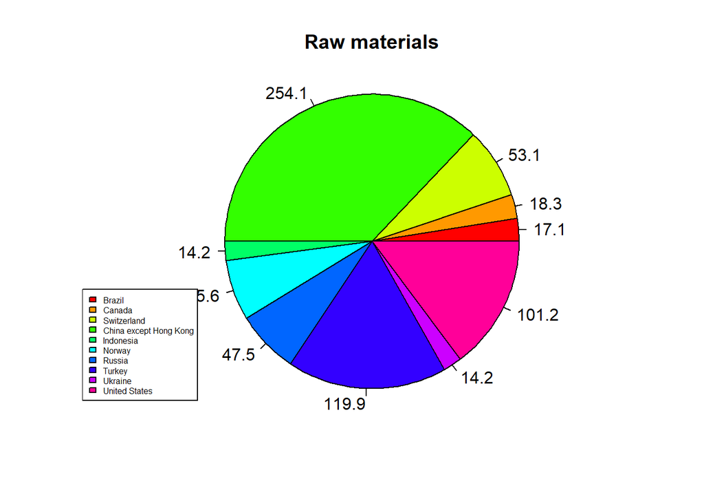

```r
p_math <- math$partner
p_math <- p_math[!duplicated(p_math)]
val_math <- list()
for (i in seq(1, length(p_math))){
  val_math[i] <- with (math, sum (values[partner == p_math[i]]))
}
v_math <- unlist(val_math)
p2 <- pie(v_math, v_math, radius = 1, main = "Raw materials", col = rainbow(length(v_math)))
legend("bottomleft", p_math, cex = 0.5,
   fill = rainbow(length(v_math)))
```

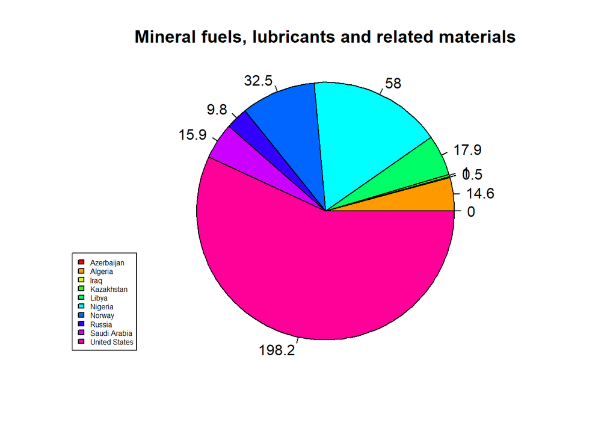

```r
p_mineral <- mineral$partner
p_mineral <- p_mineral[!duplicated(p_mineral)]
val_mineral <- list()
for (i in seq(1, length(p_mineral))){
  val_mineral[i] <- with (mineral, sum (values[partner == p_mineral[i]]))
}
v_mineral <- unlist(val_mineral)
p2 <- pie(v_mineral, v_mineral, radius = 1, main = "Mineral fuels, lubricants and related materials", col = rainbow(length(v_mineral)))
legend("bottomleft", p_mineral, cex = 0.5,
   fill = rainbow(length(v_mineral)))
```

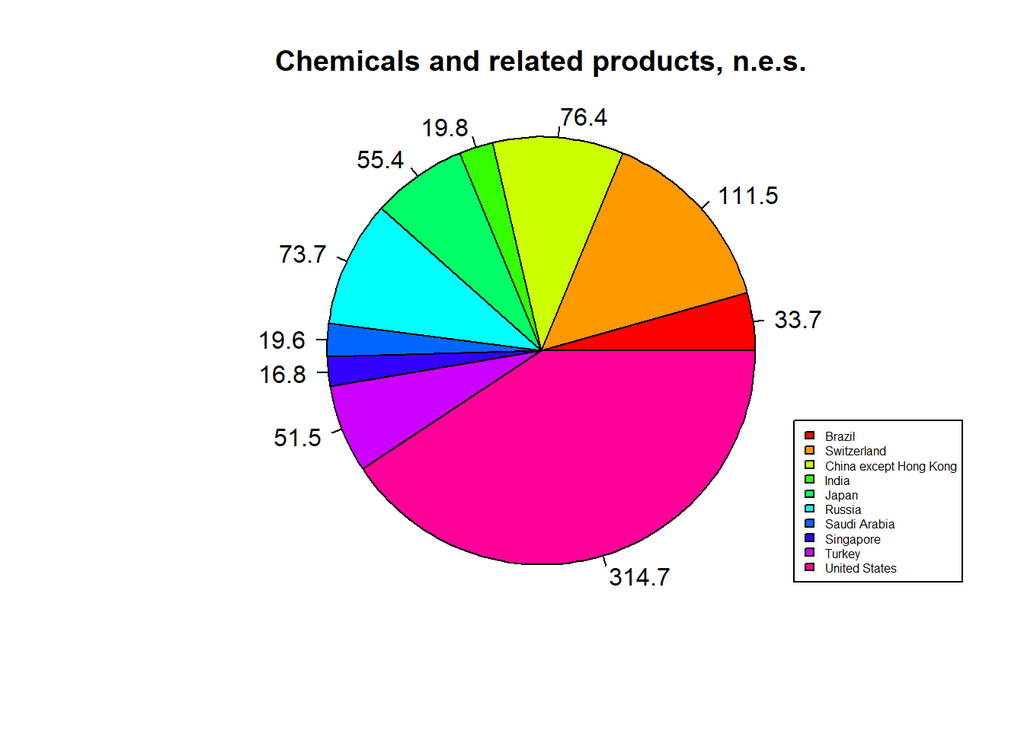

```r
p_chem <- chem$partner
p_chem <- p_chem[!duplicated(p_chem)]
val_chem <- list()
for (i in seq(1, length(p_chem))){
  val_chem[i] <- with (chem, sum (values[partner == p_chem[i]]))
}
v_chem <- unlist(val_chem)
p2 <- pie(v_chem, v_chem, radius = 1, main = "Chemicals and related products, n.e.s.", col = rainbow(length(v_chem)))
legend("bottomright", p_chem, cex = 0.5,
   fill = rainbow(length(v_chem)))
```

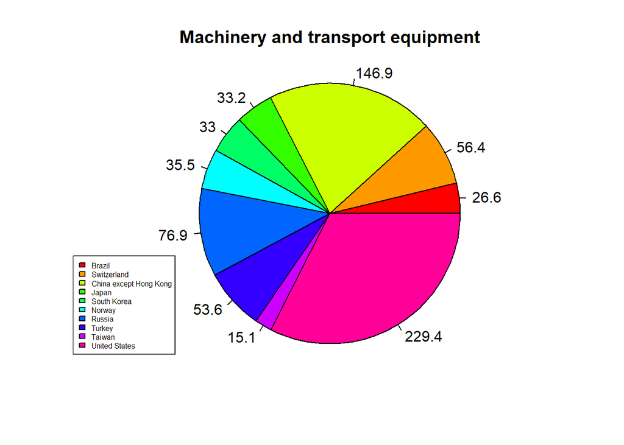

```r
p_mach <- mach$partner
p_mach <- p_mach[!duplicated(p_mach)]
val_mach <- list()
for (i in seq(1, length(p_mach))){
  val_mach[i] <- with (mach, sum (values[partner == p_mach[i]]))
}
v_mach <- unlist(val_mach)
p2 <- pie(v_mach, v_mach, radius = 1, main = "Machinery and transport equipment", col = rainbow(length(v_mach)))
legend("bottomleft", p_mach, cex = 0.5,
   fill = rainbow(length(v_mach)))
```

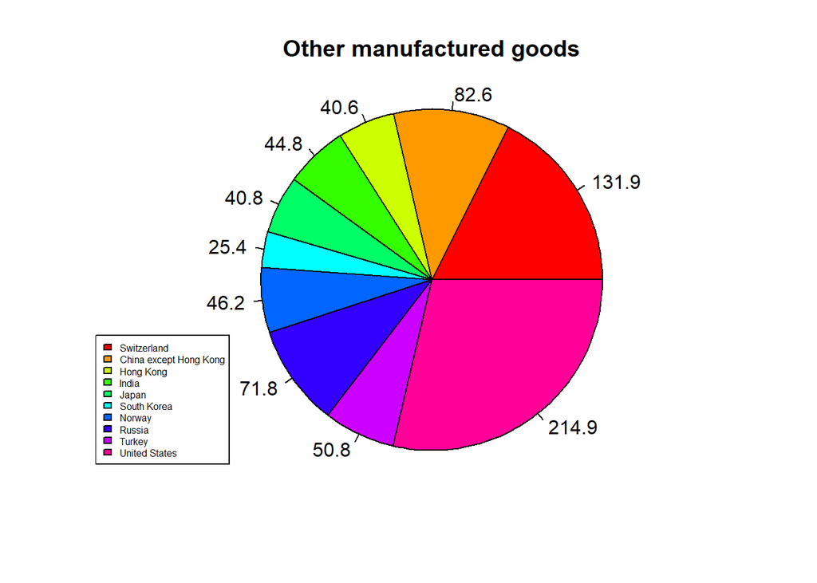

```r
p_other <- other$partner
p_other <- p_other[!duplicated(p_other)]
val_other <- list()
for (i in seq(1, length(p_other))){
  val_other[i] <- with (other, sum (values[partner == p_other[i]]))
}
v_other <- unlist(val_other)
p2 <- pie(v_other, v_other, radius = 1, main = "Other manufactured goods", col = rainbow(length(v_other)))
legend("bottomleft", p_other, cex = 0.5,
   fill = rainbow(length(v_other)))
```